# Tesla Stocks

eagbozo

The dataset can be downloaded here: https://www.kaggle.com/timoboz/tesla-stock-data-from-2010-to-2020

Load the tidyverse library and our dataset We will be applying the 5 TidyVerse Verbs from - https://teachingr.com/content/the-5-verbs-of-dplyr/the-5-verbs-of-dplyr-article.html

```r
library(tidyverse)
tsla=read_csv("TSLA.csv")
#inspect the dataset
head(tsla)
```

```
## # A tibble: 6 x 7
##   Date        Open  High   Low Close `Adj Close`   Volume
##   <date>     <dbl> <dbl> <dbl> <dbl>       <dbl>    <dbl>
## 1 2010-06-29  19    25    17.5  23.9        23.9 18766300
## 2 2010-06-30  25.8  30.4  23.3  23.8        23.8 17187100
## 3 2010-07-01  25    25.9  20.3  22.0        22.0  8218800
## 4 2010-07-02  23    23.1  18.7  19.2        19.2  5139800
## 5 2010-07-06  20    20    15.8  16.1        16.1  6866900
## 6 2010-07-07  16.4  16.6  15.0  15.8        15.8  6921700
```

*select* the first row —– ALL EXCEPT Volume.

```r
tsla[1,] %>%
  select(-Volume)
```

```
## # A tibble: 1 x 6
##   Date        Open  High   Low Close `Adj Close`
##   <date>     <dbl> <dbl> <dbl> <dbl>       <dbl>
## 1 2010-06-29    19    25  17.5  23.9        23.9
```

load the reshape pattern so we obtain a *long format* of the dataset per date (for the first row) - we will use the *melt* function.

```r
library(reshape2)
tsla[1,] %>%
  select(-Volume) %>%
  melt(id="Date")
```

```
##         Date  variable value
## 1 2010-06-29      Open 19.00
## 2 2010-06-29      High 25.00
## 3 2010-06-29       Low 17.54
## 4 2010-06-29     Close 23.89
## 5 2010-06-29 Adj Close 23.89
```

let’s plot for only 5 row readings All Variables (i.e. columns will be plotted)

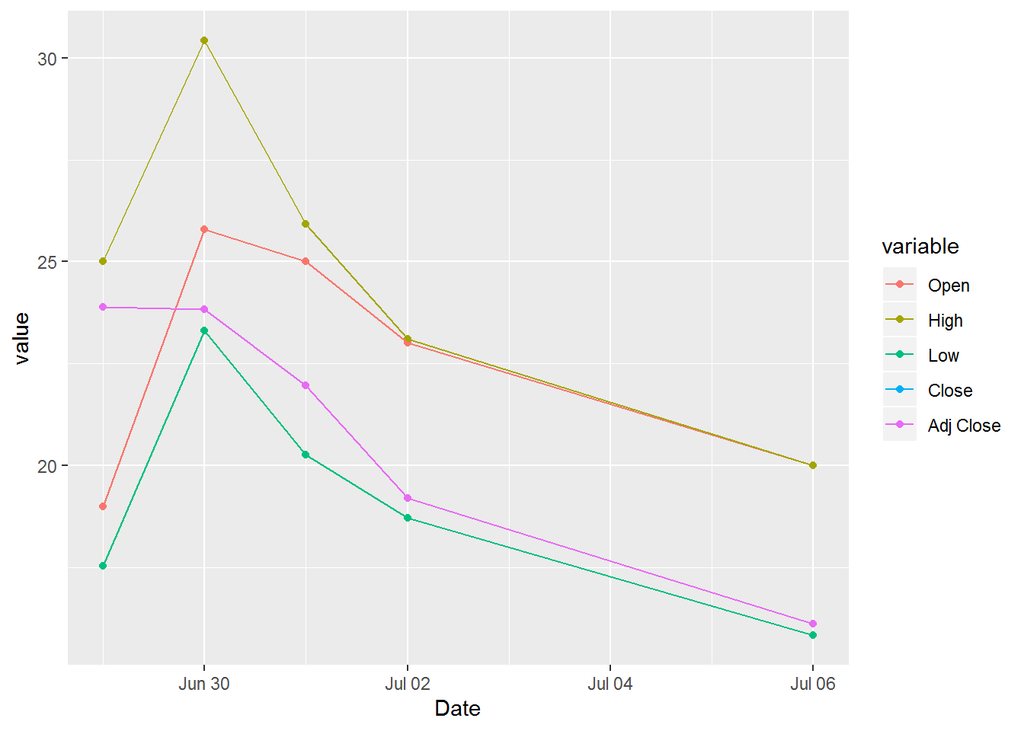

```r
library(ggplot2)
tsla[1:5,] %>%
  select(-Volume) %>%
  melt(id="Date") %>%
  ggplot() +
  geom_point(aes(x=Date, y=value,col=variable)) +
  geom_line(aes(x=Date, y=value,col=variable, group=variable))
```

include the *alpha* parameter - this influences the level of transparency (0 minimum - 1.0 maximum)

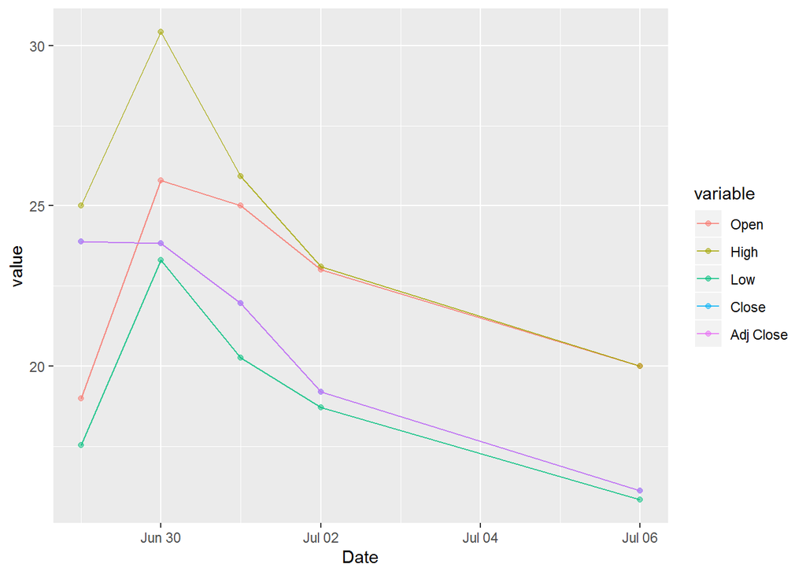

```r
tsla[1:5,] %>%
  select(-Volume) %>%
  melt(id="Date") %>%
  ggplot() +
  geom_point(aes(x=Date, y=value,col=variable), alpha=0.5) +
  geom_line(aes(x=Date, y=value,col=variable, group=variable), alpha=0.8)
```

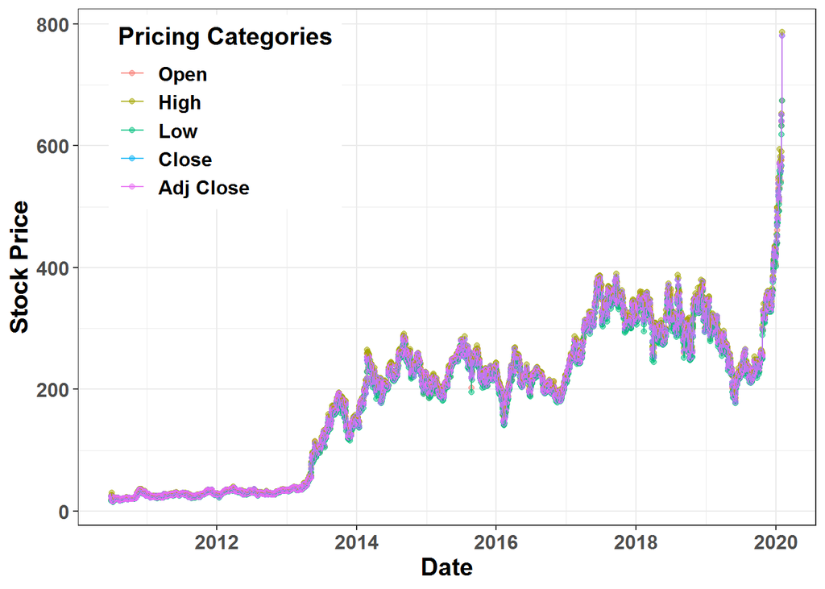

```r
tsla %>%
  select(-Volume) %>%
  melt(id="Date") %>%
  ggplot() +
  geom_point(aes(x=Date, y=value,col=variable), alpha=0.5) +
  geom_line(aes(x=Date, y=value,col=variable, group=variable), alpha=0.8)+
xlab("Date") + ylab("Stock Price") +
  labs(col = "Pricing Categories") +
  theme_bw() +
  theme(text = element_text(size = 15, face = "bold"),
        legend.position = c(0.2,0.8))
```

introduce the *facet_wrap()* function

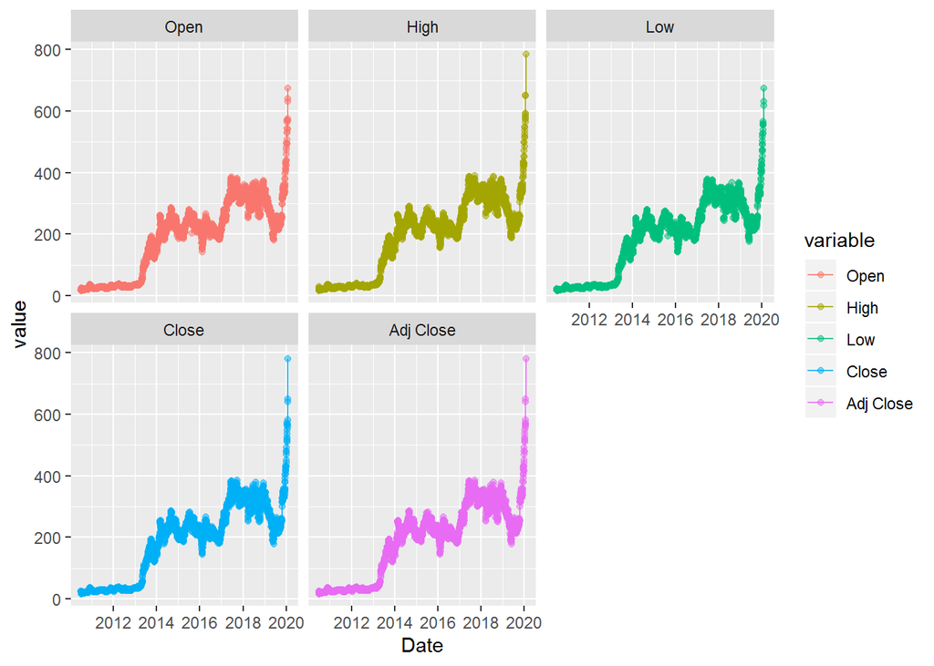

```r
tsla %>%
  select(-Volume) %>%
  melt(id="Date") %>%
  ggplot() +
  geom_point(aes(x=Date, y=value,col=variable), alpha=0.5) +
  geom_line(aes(x=Date, y=value,col=variable, group=variable), alpha=0.8)+
  facet_wrap(~variable)
```

now let’s introduce the *facet_grid()* function

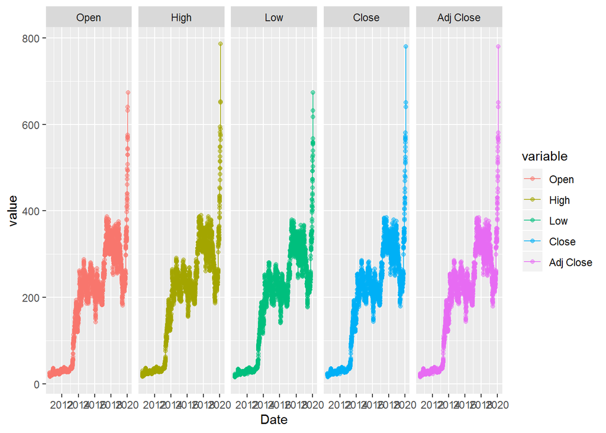

```r
tsla %>%
  select(-Volume) %>%
  melt(id="Date") %>%
  ggplot() +
  geom_point(aes(x=Date, y=value,col=variable), alpha=0.5) +
  geom_line(aes(x=Date, y=value,col=variable, group=variable), alpha=0.8)+
  facet_grid(~variable)
```

Now we will create a dataframe without the *Volume* variable

```r
tsla_vals = tsla %>%
  select(-Volume) # -"NA"
```

GET THE YEAR ONLY FROM DATE COLUMN 1. Create a new variable/column called *year*. 2. Extract the year component from the full date Note: day - %d …. month - %M … year - %Y 3. Then group by year so that we can perform the final step: 4. Calculate the mean price for each variable by using the *summarize* function from tidyverse

We will then plot our findings

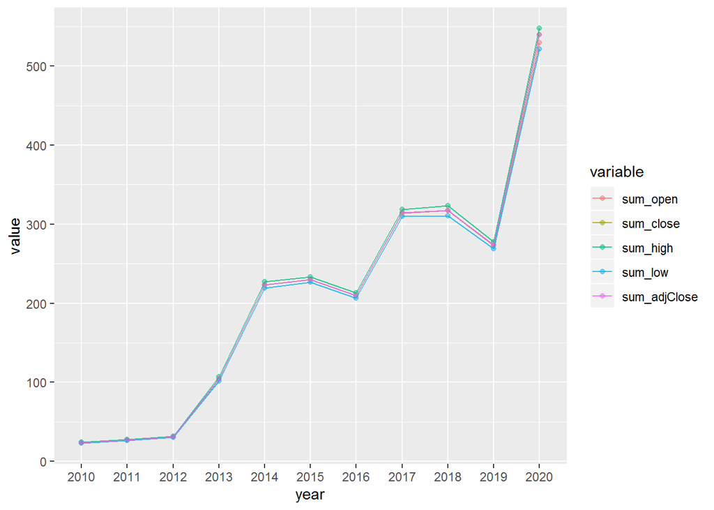

```r
tsla_vals_sum_years =tsla_vals %>%
  mutate(year=format(Date,"%Y")) %>%
  group_by(year) %>%
  summarize(mean(Open),mean(Close),mean(High),mean(Low),mean(`Adj Close`))

#rename variables(columns)
names(tsla_vals_sum_years) = c("year","sum_open","sum_close","sum_high","sum_low","sum_adjClose")

tsla_vals_sum_years %>% melt(id="year") %>%
  ggplot() +
  geom_point(aes(x=year, y=value,col=variable), alpha=0.5) +
  geom_line(aes(x=year, y=value,col=variable, group=variable), alpha=0.8)
```

The results could be linked to news events relating to Tesla at that particular period in time. https://www.reuters.com/article/us-tesla-musk-timeline/timeline-main-events-in-teslas-history-as-a-public-company-idUSKBN1KV2A0

Another example of extracting specific dates GET 2016 opening and closing values

```r
tsla_open_close_2016 = tsla %>%
  select(Date, Open,Close) %>%
  mutate(year=format(Date,"%Y")) %>%
  filter(year=="2016")
```